# Avaliação do grau de insatisfação de reclamações com o gf

Matheus Thiago, Ionésio Junior,Antonio Pedro

28/05/2019

# Entendendo o contexto do problema

Antes de começarmos, é importante entender o contexto do nosso problema:

## Quais são nossos dados?

Temos como dados, algumas ocorrências de avaliações direcionadas ao Governo Federal registradas no Reclame Aqui! Também possuímos amostras rotuladas por nível de insatisfação

```r
avaliacoes_raw <- read_csv("reclamacoes-avaliadas-20190515.csv")
```

## Mudança dos nomes das variáveis

```r
avaliacoes <- avaliacoes_raw %>% select(id = "id",
                                   orgao = "orgao",
                                    data = "data",
                                   titulo = "titulo",
                                   grupo = "Grupo que vai avaliar",
                                   mediaAvaliacao = "insatisfacao",
                                   avaliadores = "avaliadores",
                                   rangeAvaliacoes = "range.avaliacoes")
avaliacoes %>% View()
glimpse(avaliacoes)
```

```
## Observations: 60
## Variables: 8
## $ id              <dbl> 1, 17, 25, 33, 41, 49, 57, 9, 10, 18, 2, 26, 3...
## $ orgao           <chr> "ANS", "ANS", "ANS", "ANATEL", "ANATEL", "ANAT...
## $ data            <chr> "Quarta-feira, 17 de Abril de 2019 - 15:48", "...
## $ titulo          <chr> "Saúde mental PRA QUE? Cometa suicídio", "A ag...
## $ grupo           <dbl> 1, 1, 1, 1, 1, 1, 1, 1, 2, 2, 2, 2, 2, 2, 2, 2...
## $ mediaAvaliacao  <dbl> 5.0, 3.0, 2.5, 2.0, 1.5, 2.0, 2.0, 3.0, 4.5, 3...
## $ avaliadores     <dbl> 6, 6, 6, 6, 6, 6, 6, 6, 6, 6, 5, 6, 6, 6, 6, 5...
## $ rangeAvaliacoes <dbl> 1, 3, 2, 1, 3, 2, 3, 1, 1, 2, 0, 1, 2, 1, 1, 2...
```

## Qual nosso objetivo?

Dado estas informações, precisamos extrair características importantes para descrever o comportamento dos dados

## Em termos gerais, como o governo é avaliado

Para termos uma visão geral, podemos tentar avaliar em termos gerais, como o governo é avaliado em relação aos seus serviços.

##Adicionando quantidade de letras em Capslock do titulo e do texto

```r
avaliacoes_raw$Casplock_no_titulo <- str_count(avaliacoes_raw$titulo, "\\b[A-Z]{2,}\\b")
avaliacoes_raw$Casplock_no_texto <- str_count(avaliacoes_raw$texto, "\\b[A-Z]{2,}\\b")
```

### Média

Uma das métricas que temos para realizar essa avaliação é a média.

```r
media_insatisfacao <- mean(x = avaliacoes_raw$insatisfacao)
message("Média de insatisfação: ", media_insatisfacao)
```

```
## Média de insatisfação: 2.63333333333333
```

Como podemos ver, em termos de média, o governo possui um nível de insatisfação relativamente baixo (estando abaixo da métade do nível de insatisfação total).

### Mediana

Outra métrica interessante para uma visão geral, é a mediana, ela evita viés criado por possíveis “outliers”

```r
mediana_insatisfacao <- median(x = avaliacoes_raw$insatisfacao)
message("Médiana de insatisfação: ", mediana_insatisfacao)
```

```
## Médiana de insatisfação: 2.5
```

A partir destas métricas, podemos concluir que dentre as amostras fornecidas e rotuladas, em termos de ambas as métricas(media e mediana), o governo possui um nível de insatisfação baixo/médio.

## Avaliando o nível de uniformidade das avaliações

Dado que agora temos uma visão geral sobre o nível de insatisfação.Podemos avaliar o nível de uniformidade, espaçamento das avaliações.

```r
m_av_range <- mean(x = avaliacoes_raw$range.avaliacoes)
message("Média de intervalo entre avaliações: ", m_av_range)
```

```
## Média de intervalo entre avaliações: 1.71666666666667
```

Como podemos ver,temos um intervalo alto entre a classificação das avaliações.Isso denota um problema de confiabilidade em relação os métodos de avaliação.Pois, em termos gerais, cada reclamação possui avaliações com quase dois pontos de diferença em relação a sua classificação (o que é alto, se considerado que temos um intervalo máximo de 5 pontos).

## Números das avaliações por orgão

```r
table(avaliacoes$orgao)
```

```
##
## ANATEL    ANS
##     30     30
```

## Gráficos de barras

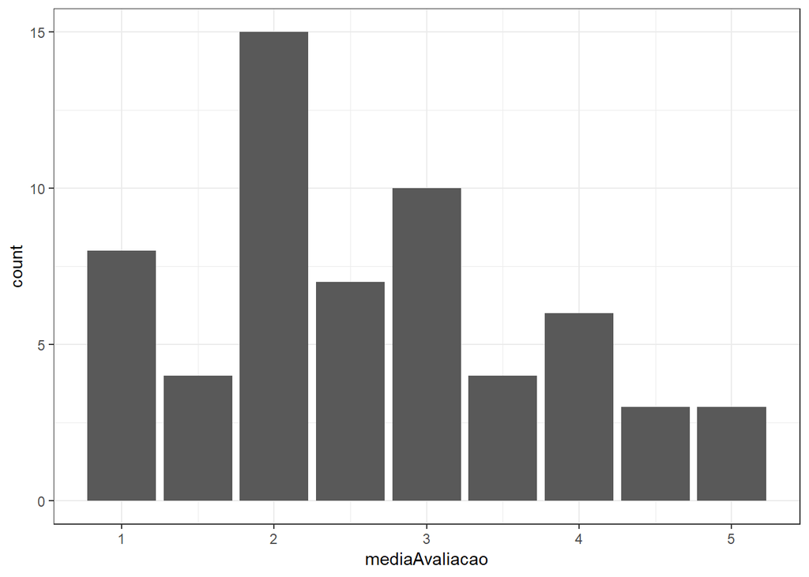

```r
ggplot(avaliacoes %>% filter(!is.na(mediaAvaliacao))) +
    geom_bar(mapping = aes(x = mediaAvaliacao))
```

Quantidade total das Médias das Avaliações da ANATEL e ANS, onde o eixo x são as médias e o eixo y as quantidades para cada média.

## Avaliação das Médias da ANATEL

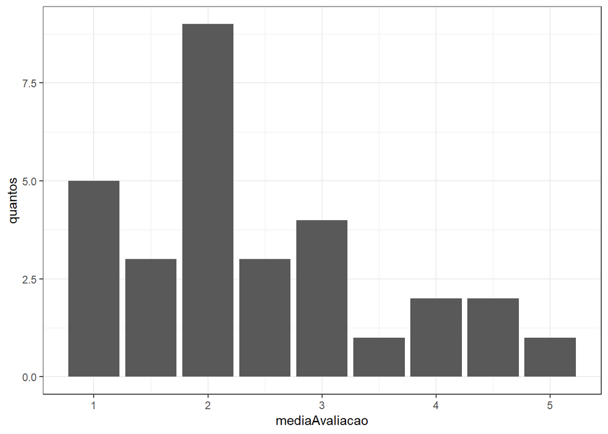

```r
avaliacoes %>% filter(orgao == "ANATEL") %>% filter(!is.na(mediaAvaliacao)) %>% group_by(mediaAvaliacao) %>% summarise(quantos = n()) %>% ggplot() + geom_col(mapping = aes(x = mediaAvaliacao, y = quantos))
```

Quantidades das Médias das Avaliações da ANATEL, onde o eixo x são as médias e o eixo y as quantidades para cada média.

## Avaliação das Médias da ANS

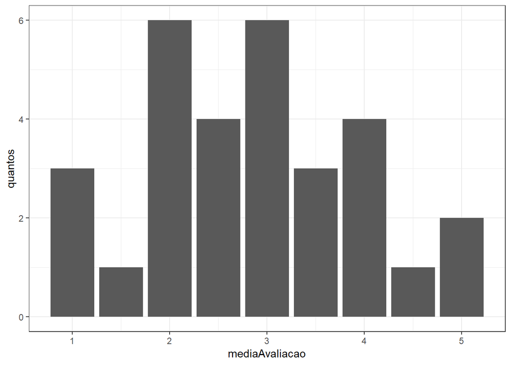

```r
avaliacoes %>% filter(orgao == "ANS") %>% filter(!is.na(mediaAvaliacao)) %>% group_by(mediaAvaliacao) %>% summarise(quantos = n()) %>% ggplot() + geom_col(mapping = aes(x = mediaAvaliacao, y = quantos))
```

Quantidades das Médias das Avaliações da ANS, onde o eixo x são as médias e o eixo y as quantidades para cada média.

##Regressão entre as variaveis insatisfacão e quantidade de letras em casplock no texto

```r
dados_regressao <- data.frame(avaliacoes_raw$insatisfacao, avaliacoes_raw$Casplock_no_texto) #criando um data frame
is.data.frame(dados_regressao) #verifica se dados é um data.frame
```

```
## [1] TRUE
```

```r
regressao<-lm(avaliacoes_raw$insatisfacao~avaliacoes_raw$Casplock_no_texto,data=dados_regressao)
regressao
```

```
##
## Call:
## lm(formula = avaliacoes_raw$insatisfacao ~ avaliacoes_raw$Casplock_no_texto,
##     data = dados_regressao)
##
## Coefficients:
##                      (Intercept)  avaliacoes_raw$Casplock_no_texto
##                          2.61610                           0.00188
```

```r
summary(regressao)
```

```
##
## Call:
## lm(formula = avaliacoes_raw$insatisfacao ~ avaliacoes_raw$Casplock_no_texto,
##     data = dados_regressao)
##
## Residuals:
##     Min      1Q  Median      3Q     Max
## -1.6199 -0.6335 -0.1246  0.8679  2.3783
##
## Coefficients:
##                                  Estimate Std. Error t value Pr(>|t|)
## (Intercept)                      2.616096   0.152269  17.181   <2e-16 ***
## avaliacoes_raw$Casplock_no_texto 0.001880   0.004336   0.434    0.666
## ---
## Signif. codes:  0 '***' 0.001 '**' 0.01 '*' 0.05 '.' 0.1 ' ' 1
##
## Residual standard error: 1.139 on 58 degrees of freedom
## Multiple R-squared:  0.003232,   Adjusted R-squared:  -0.01395
## F-statistic: 0.1881 on 1 and 58 DF,  p-value: 0.6661
```

##GRAFICO DA REGRESSÃO

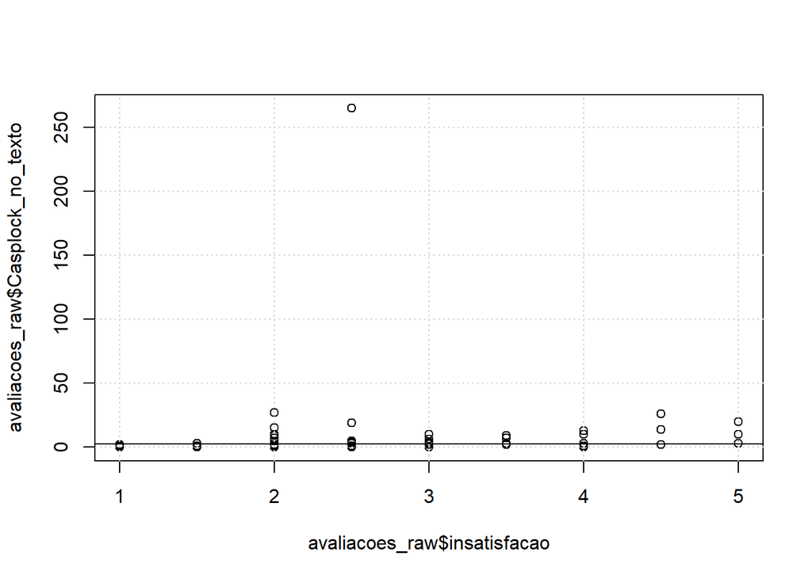

```r
#plot(x,y) ou
z = plot(avaliacoes_raw$insatisfacao, avaliacoes_raw$Casplock_no_texto)
grid(z) #aplicando grid ao gráfico
abline(regressao)
```

##Regressão entre as variaveis insatisfacão e quantidade de letras em casplock no titulo

```r
dados_regressao_titulo <- data.frame(avaliacoes_raw$insatisfacao, avaliacoes_raw$Casplock_no_texto) #criando um data frame
is.data.frame(dados_regressao_titulo) #verifica se dados é um data.frame
```

```
## [1] TRUE
```

```r
regressao<-lm(avaliacoes_raw$insatisfacao~avaliacoes_raw$Casplock_no_titulo,data=dados_regressao_titulo)
regressao
```

```
##
## Call:
## lm(formula = avaliacoes_raw$insatisfacao ~ avaliacoes_raw$Casplock_no_titulo,
##     data = dados_regressao_titulo)
##
## Coefficients:
##                       (Intercept)  avaliacoes_raw$Casplock_no_titulo
##                           2.64704                           -0.01612
```

```r
summary(regressao)
```

```
##
## Call:
## lm(formula = avaliacoes_raw$insatisfacao ~ avaliacoes_raw$Casplock_no_titulo,
##     data = dados_regressao_titulo)
##
## Residuals:
##    Min     1Q Median     3Q    Max
## -1.647 -0.647 -0.139  0.853  2.385
##
## Coefficients:
##                                   Estimate Std. Error t value Pr(>|t|)
## (Intercept)                        2.64704    0.16453  16.088   <2e-16 ***
## avaliacoes_raw$Casplock_no_titulo -0.01612    0.08652  -0.186    0.853
## ---
## Signif. codes:  0 '***' 0.001 '**' 0.01 '*' 0.05 '.' 0.1 ' ' 1
##
## Residual standard error: 1.14 on 58 degrees of freedom
## Multiple R-squared:  0.0005985,  Adjusted R-squared:  -0.01663
## F-statistic: 0.03473 on 1 and 58 DF,  p-value: 0.8528
```

##GRAFICO DA REGRESSÃO

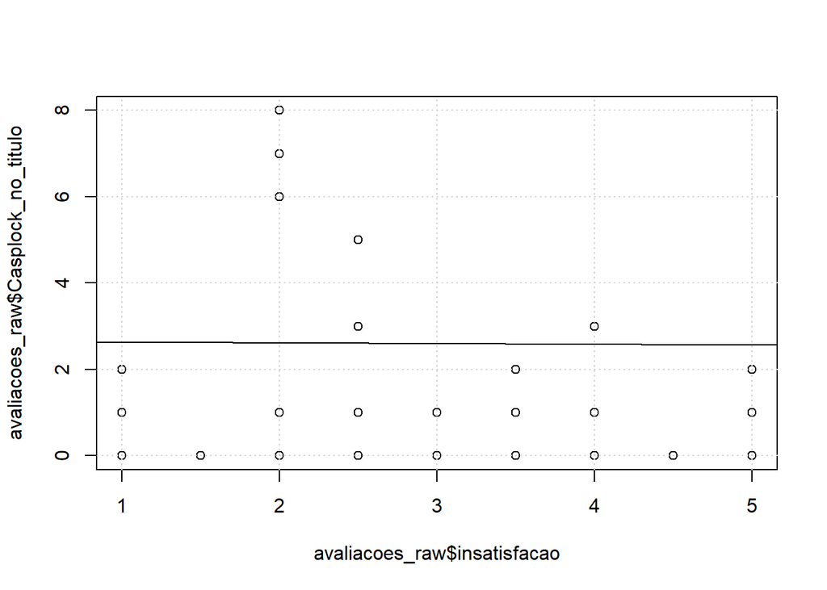

```r
#plot(x,y) ou
z = plot(avaliacoes_raw$insatisfacao, avaliacoes_raw$Casplock_no_titulo)
grid(z) #aplicando grid ao gráfico
abline(regressao)
```